# Project RIL Population Z015

Bashir,I. (2022)

21/04/2022

## Introduction

Both breeders and geneticists are interested in mapping quantitative trait loci (QTLs) (Kao, Zeng, and Teasdale 1999). The null hypothesis used to determine that a QTL is absent is tested in QTL mapping approaches such as interval mapping and composite interval mapping (Lander and Botstein 1989; Zhang et al. 2006; Zeng 1994). These techniques have been useful in identifying QTL responsible for a variety of quantitative features with agronomic, biological, or biomedical significance. The permutation test strategy described by Churchill and Doerge (Churchill and Doerge 1994; R. W. Doerge and Churchill 1996) is a different approach to determining critical threshold. The conceptual simplicity, distribution-free character, and application in various population configurations are all advantages of this technique. The computational workload is a significant disadvantage. For example, to establish a critical threshold for a genome-wide type-I error rate of 0.01, at least 10 000 permutations are necessary (R. Doerge and Rebaı̈ 1996). A sample of 1000 permutations is usually considered sufficient for a type-I error of 0.05 (Churchill and Doerge 1994). Permutations can be a significant task in typical applications where several attributes must be assessed. In other words, the accuracy log likelihood ratio (LOD) threshold can be determined using the permutation test.

## Material and Methods + Results:

QTLs were mapped based on the adjusted means by single marker analysis (SMA), interval mapping (IM), composite interval mapping (CIM) and multiple interval mapping (MIM) was done by using R package `qtl` Broman et al. (2003) in RStudio RStudio Team (2022) .

Following steps were followed mentioned as

### Linkage Map

#### Loading Data

```r
library(qtl)
maize <- read.cross(format="csv", file="data/population_Z015.csv", genotypes=c("0", "1", "2"), crosstype = "riself")
```

```
##  --Read the following data:
##   185  individuals
##   1106  markers
##   33  phenotypes
```

```
##  --Cross type: riself
```

#### Data Summary

```r
summary(maize)
```

```
##     RI strains via selfing
##
##     No. individuals:    185
##
##     No. phenotypes:     33
##     Percent phenotyped: 100
##
##     No. chromosomes:    1
##         Autosomes:      0
##
##     Total markers:      1106
##     No. markers:        1106
##     Percent genotyped:  91.9
##     Genotypes (%):      AA:51.2  BB:48.8
```

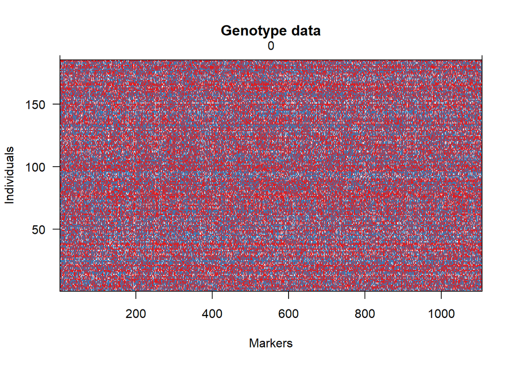

```r
geno.image(maize)
```

#### Chi_squared tests for segregation distortion:

```r
gt.maize <- geno.table(maize)
gt.maize
```

```
##                chr missing  AA  BB      P.value
## PZB01461.1       0      28  99  58 1.067306e-03
## PZA00951.1       0      16  81  88 5.902585e-01
## PHM1870.20       0      17  85  83 8.773706e-01
## PZA03521.1       0      11  89  85 7.617076e-01
## ZHD1.1           0      11  66 108 1.452491e-03
## PZA03488.1       0       4  91  90 9.407483e-01
## PZA02564.2       0      21  73  91 1.598537e-01
## PZA02274.1       0       7  98  80 1.772865e-01
## PHM3668.12       0      16  93  76 1.909777e-01
## PZA03064.6       0       7  82  96 2.940197e-01
## PZA03692.1       0      14  84  87 8.185458e-01
## PZA03191.1.4     0      12 119  54 7.738137e-07
## PHM9695.8        0       8  81  96 2.595442e-01
## PZA03671.1       0      10  60 115 3.215956e-05
## PZB01017.1       0      32  75  78 8.083652e-01
## PZA00912.2       0      11  80  94 2.885367e-01
## PZA03322.5.3     0      27  80  78 8.735811e-01
## PHM4203.11       0      10  88  87 9.397430e-01
## PZA00865.1       0      35  77  73 7.439715e-01
## PZA01447.1       0      15 107  63 7.391071e-04
## PZA02398.2       0      13  93  79 2.857506e-01
## PZA03154.4       0       6 117  62 3.941318e-05
## PZA03265.3       0      22  84  79 6.953315e-01
## PZA01879.1       0      12  80  93 3.229706e-01
## PZA00878.2       0      13  99  73 4.742539e-02
## PZA01238.1.2     0      11  94  80 2.885367e-01
## PZA02427.1       0      32  92  61 1.220361e-02
## PZA01451.1       0       9  82  94 3.657123e-01
## PHM3171.5        0      19  82  84 8.766399e-01
## PHM10321.11      0      24  74  87 3.055786e-01
## PZA01905.12      0       9  91  85 6.510766e-01
## PHM5798.39       0      21  81  83 8.758961e-01
## PZA02490.1       0       8  93  84 4.987350e-01
## PZA02418.2       0      10  90  85 7.054570e-01
## PZA00175.2       0      11  83  91 5.441971e-01
## PZA01946.7       0      12  92  81 4.029780e-01
## PZA01527.1       0       6  89  90 9.404188e-01
## PHM4711.14       0      13  68 104 6.051564e-03
## PZB01647.1       0      11  83  91 5.441971e-01
```

[output cut: 1052 more lines]

```
## PHM1962.33       0      10  81  94 3.257514e-01
## PZA01619.1       0      12  92  81 4.029780e-01
## PZA02390.1       0      13  92  80 3.601961e-01
## PZA01802.3       0      20  82  83 9.379475e-01
## PZB00079.4       0      13  88  84 7.603683e-01
## PZA00245.20      0      12  88  85 8.195796e-01
## PHM5484.22       0       9  90  86 7.630246e-01
## PZA00643.13      0      24  79  82 8.130966e-01
## PHM1275.22       0      19  85  81 7.562110e-01
## PZA00380.10      0      25 102  58 5.042182e-04
## PZA03058.22.21   0      11  80  94 2.885367e-01
## PZB02002.1       0      15 111  59 6.657149e-05
## PZA00339.4       0      10  79  96 1.987646e-01
## PZA00447.8       0       9  85  91 6.510766e-01
## PZA00889.2       0       5  78 102 7.363827e-02
```

```r
head(gt.maize)
```

```
##            chr missing AA  BB     P.value
## PZB01461.1   0      28 99  58 0.001067306
## PZA00951.1   0      16 81  88 0.590258451
## PHM1870.20   0      17 85  83 0.877370556
## PZA03521.1   0      11 89  85 0.761707564
## ZHD1.1       0      11 66 108 0.001452491
## PZA03488.1   0       4 91  90 0.940748272
```

```r
table(gt.maize$P.value <0.05)
```

```
##
## FALSE  TRUE
##   865   241
```

```r
table(gt.maize$P.value <0.05/totmar(maize))
```

```
##
## FALSE  TRUE
##  1043    63
```

#### Estimation of the pairwise or two-point recombination fractions:

Estimation of the pairwise recombination fractions and their respective LOD scores by using the function `est.rf()`. The map is not estimated yet, so `qtl package` interprets each marker 10 cM apart. From the `plotRF()` function, we notice that 1106 markers have not been assigned to linkage groups yet.

```r
maize <- est.rf(cross = maize)
dim(maize$rf)
```

```
## [1] 1106 1106
```

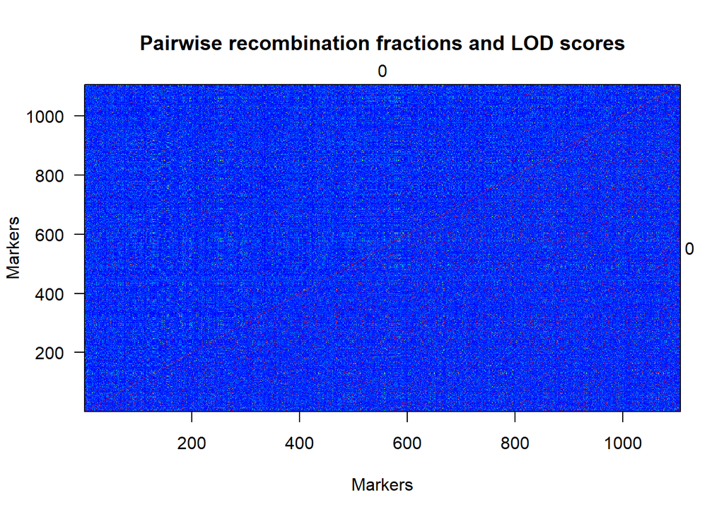

```r
plotRF(maize, col.scheme = "redblue")
```

Again, this `heatmap` presents both the estimates (above diagonal) and LOD scores (below diagonal). The  
`heatmap` shows more blue, colder colors for non-linked markers (i.e. r $\approx$ 0.5 and low LOD), and more red, warmer colors for the linked markers (i.e. r $<$ 0.35 and high ). It can now see how many groups are formed by with these markers:

#### Marker grouping:

Once we have the pairwise recombination fraction estimates, we provide the maximum recombination fraction (`max.rf` argument) and minimum LOD score (`min.lod` argument). This values are provided to the function `formLinkageGroups()` and they are used to see whether two markers are linked or not while avoiding false positives. For `max.rf` , we use something around 0.38, which is the value maximum recombination fraction of 0.50 when converted via Kosambi map function:

$$m_ij = \frac{1}{4} log \binom {1+2r_ij}{1-2r_ij}$$

A recombination fraction as big as 0.50 means that two markers are independently segregating.

```r
maize <- formLinkageGroups(maize, max.rf=0.38, min.lod=6.25, reorgMarkers=TRUE)
summary(maize)
```

```
##     RI strains via selfing
##
##     No. individuals:    185
##
##     No. phenotypes:     33
##     Percent phenotyped: 100
##
##     No. chromosomes:    10
##         Autosomes:      1 2 3 4 5 6 7 8 9 10
##
##     Total markers:      1106
##     No. markers:        175 139 130 127 111 106 85 78 78 77
##     Percent genotyped:  91.9
##     Genotypes (%):      AA:51.2  BB:48.8
```

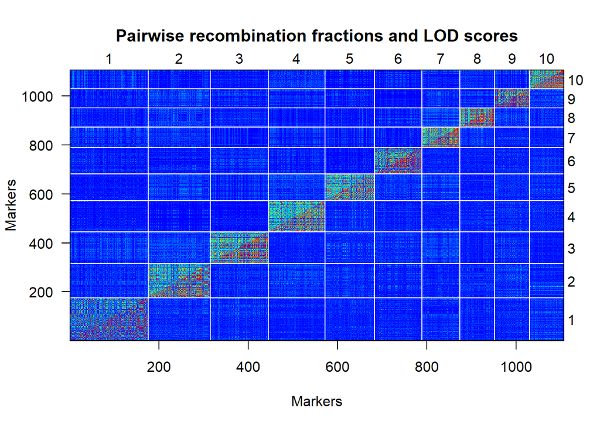

```r
plotRF(maize, col.scheme = "redblue")
```

#### Marker Ordering:

is done by using Multidimensional Scale (MDS) from `MDSMap` implements the MDS algorithm, and `MAPpoly` has a nice wrapper function called `mds_mappoly`. This function only needs the recombination fraction matrix estimated by `R/qtl`, and it returns a new order that can be used by `switch.order()` `R/qtl` function to yield a newly ordered linkage group.  
First, `MAPpoly package` was installed and MDS algorithm used to build a chosen linkage group.

```r
#library(mappoly)
```

```r
#getMDSorder <- function(cross, chr){
#  markers <- match(names(cross$geno[[chr]]$map), colnames(cross$rf))
#  mat <- cross$rf[markers,markers]
#  rec.mat <- lod.mat <- matrix(rep(NA, length(markers)^2), nrow =length(markers))
#  colnames(rec.mat) <- colnames(lod.mat) <- rownames(rec.mat) <- rownames(lod.mat) <- colnames(mat)
#  lod.mat[upper.tri(lod.mat)] <- mat[upper.tri(mat)]
#  lod.mat[lower.tri(lod.mat)] <- t(lod.mat)[lower.tri(lod.mat)]
#  rec.mat[lower.tri(rec.mat)] <- mat[lower.tri(mat)]
#  rec.mat[upper.tri(rec.mat)] <- t(rec.mat)[upper.tri(rec.mat)]
#  input.mat <- NULL
#  input.mat$rec.mat <- rec.mat
#  input.mat$lod.mat <- lod.mat
#  mds.map <- mappoly::mds_mappoly(input.mat)
#  mds.ord <- match(as.character(mds.map$locimap$locus), colnames(mat))
#  return(mds.ord)
#}
```

We’ll create a new object called `maize.mds` which is a copy of our original cross object maize , so that we can update the ordering within `maize.mds` only. In addition, we’ll create an empty object called `loglik.mds` to store the log-likelihood of the orderings obtained using MDS:

```r
#maize.mds <- maize
#loglik.mds <- c()
```

#### Reordering markers into each of the 10 linkage groups:

```r
#for(c in 1:10) {
#  mds.ord <- getMDSorder(cross = maize.mds, chr = c)
#  maize.mds <- switch.order(cross = maize.mds, chr=c, order=mds.ord)
#  plotRF(maize.mds, chr=c, col.scheme = "redblue")
#  print(pull.map(maize.mds, chr = c))
#  print(loglik.mds[c] <- attr(maize.mds$geno[[c]]$map, "loglik"))
#}
```

#### Final map:

```r
#knitr::kable(cbind(summaryMap(maize.mds), log.likelihood=c(loglik.mds, sum(loglik.mds))))
```

```r
#plotMap(maize.mds)
```

```r
#plotRF(maize.mds, col.scheme = "redblue")
```

```r
#save.image("maize_mds.Rdata")
```

```r
load("maize_mds.RData")
```

```r
summaryMap(maize.mds)
```

```
##         n.mar length ave.spacing max.spacing
## 1         175  180.6         1.0        13.6
## 2         139  189.0         1.4        14.5
## 3         130  142.1         1.1        17.0
## 4         127  144.5         1.1        11.5
## 5         111  149.9         1.4        13.8
## 6         106  108.4         1.0         9.0
## 7          85  101.4         1.2        13.6
## 8          78  138.6         1.8        17.0
## 9          78  107.1         1.4        13.6
## 10         77   86.8         1.1        13.5
## overall  1106 1348.4         1.2        17.0
```

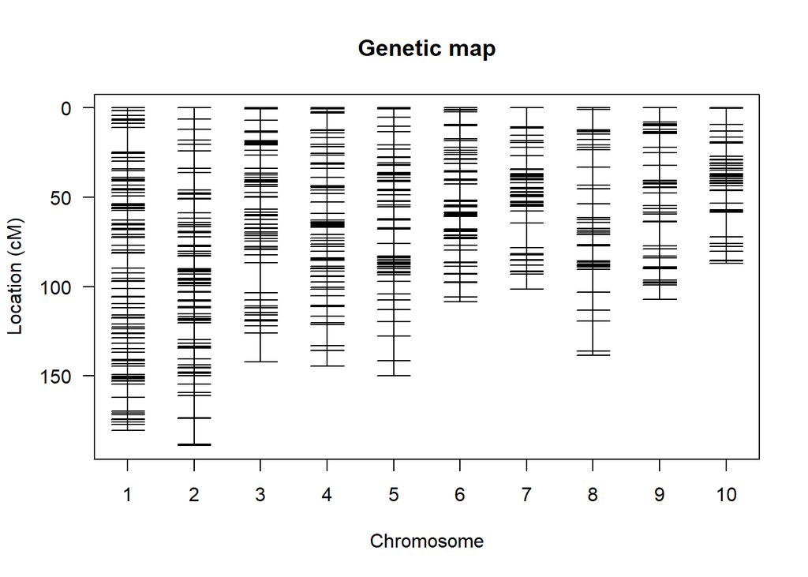

```r
plotMap(maize.mds)
```

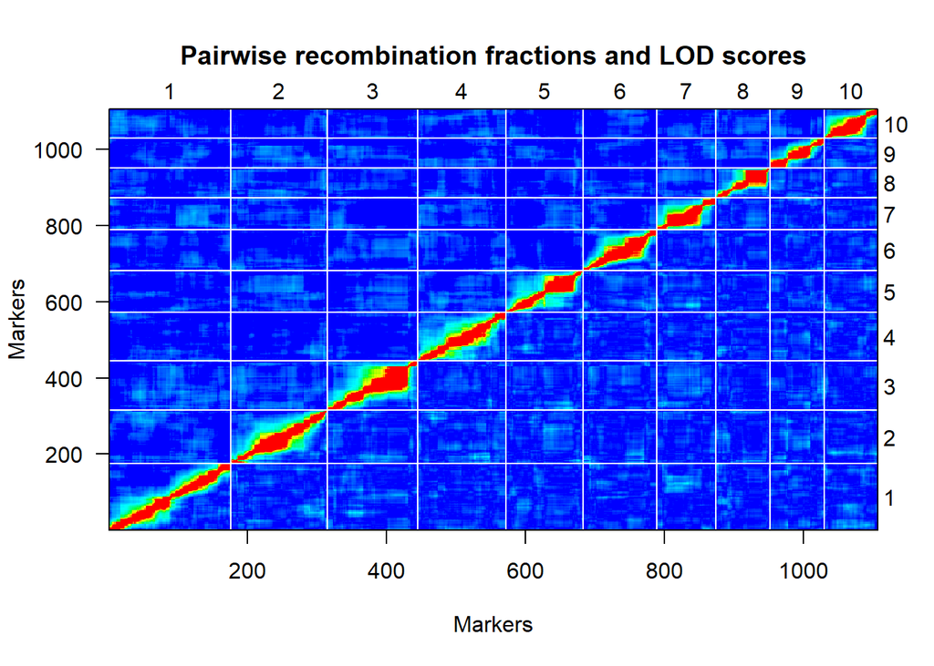

```r
plotRF(maize.mds, col.scheme = "redblue")
```

## QTL Mapping

Used the linkage map to perform interval mapping (IM) for the trait “PlantHeight”. Do not forget to run permutation tests to identify the LOD threshold to declare QTL at an alpha level of 0.05. Results for the QTL peak within each QTL region should be presented as a table showing QTL chromosome and location of its peak, their effects, associated LOD scores, and R-squared.

#### Single marker analysis (SMA)

Our first analysis involves testing for associations between each marker and the trait `PlantHeight`. So, by running the function `scanone()` with method = `mr` , which stands for “marker regression”, which provide us the position along with LOD score of each marker on all chromosomes.

Then the `plot()` function gives us a graphs represents position of each markers on chromosomes 1 to 10. when `summary()` function QTL mapping object gives us the information of marker with highest LOD value and their position on relative chromosome.

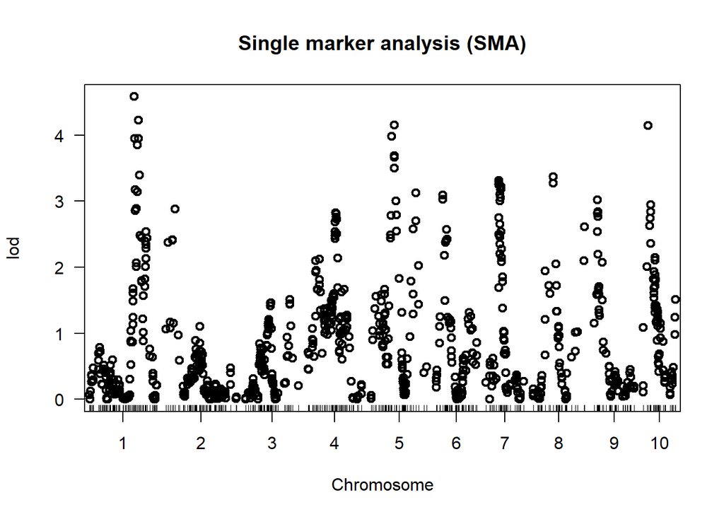

```r
maize.mr <- scanone(maize.mds, pheno.col = "PlantHeight", method = "mr")
plot(maize.mr, type = "p", main = "Single marker analysis (SMA)")
```

```r
summary(maize.mr)
```

```
##              chr    pos  lod
## PZB01647.1     1 121.11 4.58
## PZA01887.1     2  24.10 2.88
## PHM12859.7     3 118.57 1.51
## PZA00635.7     4  74.17 2.83
## PZA03275.4.1   5  62.15 4.15
## PZA00904.1     6  18.24 3.09
## PZB00547.3     7  34.57 3.31
## PZA02722.1     8  53.70 3.37
## PZA01901.1     9   9.69 3.02
## PZA02095.10   10  12.87 4.14
```

```r
maize.perm.mr <- scanone(cross = maize.mds, pheno.col = "PlantHeight", method = "mr",
                         n.perm = 1000, verbose = FALSE, n.cluster = 2)
```

```
##  -Running permutations via a cluster of 2 nodes.
```

```r
lod.sma <- summary(maize.perm.mr, alpha = 0.05)
lod.sma
```

```
## LOD thresholds (1000 permutations)
##     lod
## 5% 3.13
```

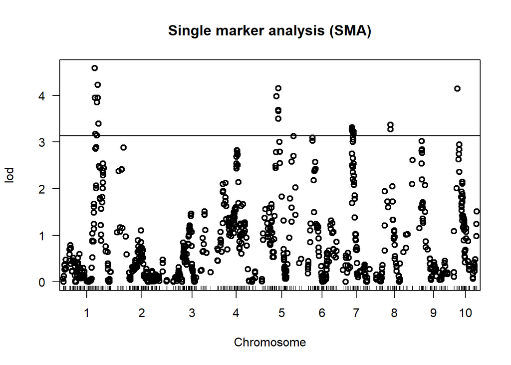

```
## integer(0)
```

```r
plot(maize.mr, type = "p", main = "Single marker analysis (SMA)") +abline(h = lod.sma)
```

```r
maize.mr.sig <- summary(maize.mr, perms = maize.perm.mr, alpha = 0.05)
maize.mr.sig
```

```
##             chr   pos  lod
## PZA03001.15   1 121.1 4.58
## PZA01681.1    5  62.2 4.15
## PZB00547.3    7  34.6 3.31
## PZA02722.1    8  53.7 3.37
## PZA02095.10  10  12.9 4.14
```

#### Interval mapping (IM)

is a QTL mapping method that allows the systematic search for QTL along a linkage map, including the region between two markers, which were not directly scored. The strategy here is to consider the QTL genotype as missing data, and use the flanking markers to infer the QTL genotype probability. The way we compute QTL genotype probabilities conditional on the available data considers the multipoint information from the genetic map. Then, we fit a linear model every position along the genetic map, and test whether there is a QTL or not.

In order to perform the test statistics, we need to estimate the parameters from the model. So, in this study we use an approximation method least squares estimators, using `Haley-Knott (HK)` regression.

In order to run IM, we calculate the QTL genotype probability within marker intervals, conditional on the genetic map. We use the function `calc.genoprob()` . The argument `step = 1` defines the step size in which the probability needs to be calculated. So, In our study we calculate at every 1 `cM`.

The `scanone()` is same as of SMA but we need to define the estimation method `hk` (least squares via Haley-Knott regression).

```r
maize.mds <- calc.genoprob(cross = maize.mds, step = 1)
maize.im <- scanone(cross = maize.mds, pheno.col = "PlantHeight", method = "hk")
summary(maize.im)
```

```
##             chr    pos  lod
## PZB01647.1    1 121.11 4.14
## PZA01887.1    2  24.10 2.81
## PZA00948.1    3  67.58 1.60
## c4.loc77      4  77.00 3.06
## c5.loc58      5  58.00 4.44
## c6.loc18      6  18.00 3.23
## c7.loc39      7  39.00 3.30
## c8.loc54      8  54.00 2.94
## PZA01901.1    9   9.69 3.13
## PZA02095.10  10  12.87 4.49
```

In order to know the critical value to identify QTL using permutations, we first run the `scanone()` function with the arguments method = `"hk"` and n.perm = 1000 . Then the function `summary()` shows the LOD threshold for a given $a$ 0.05 level.

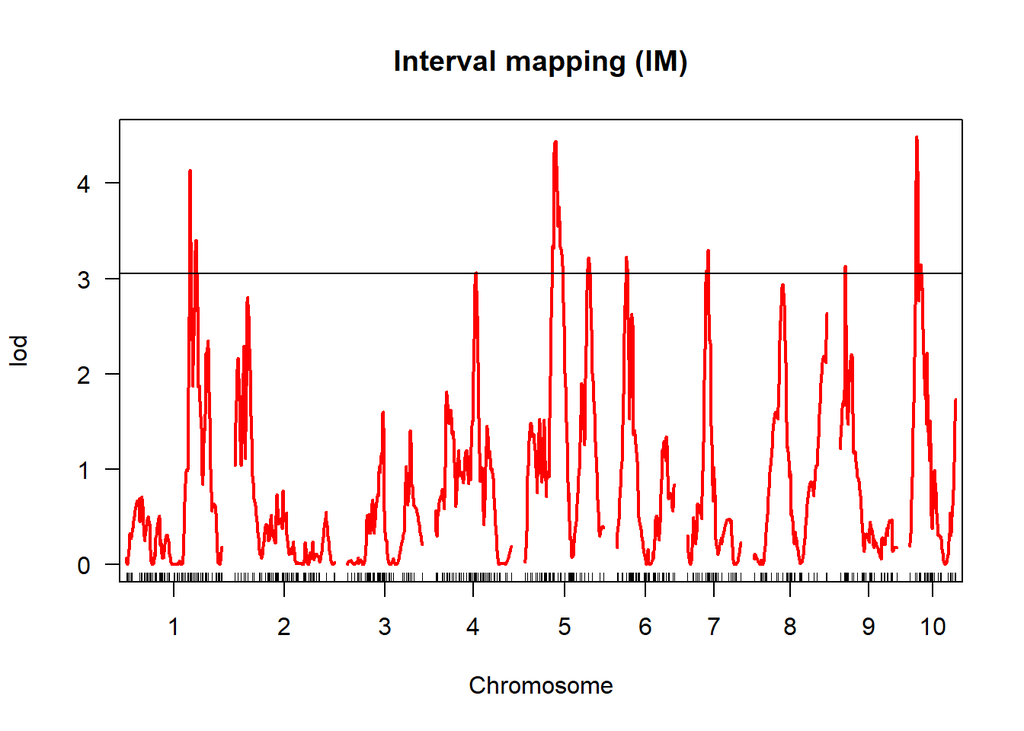

```
## integer(0)
```

```r
#perm.im <- scanone(cross = maize.mds, pheno.col = "PlantHeight", method = "hk", n.perm = 1000, n.cluster = 2)
#save(perm.im, file = "perm.im.RData")
load("perm.im.RData")
lod.im <- summary(perm.im, alpha = 0.05)
plot(maize.im, col = "red", main = "Interval mapping (IM)")+abline(h= lod.im)
```

So, now to identify the significant QTL on the chromosome above threshold level was done by using summary function and running on the object created before `maize.im`.

Finally, the `makeqtl()` and `fitqtl()` was used to show the QTL effect estimates for an RIL population based on an object derived from the function `sim.geno()`. For this purpose , we a multiple QTL model to get the estimation effects of significant QTL on our trait Plant height.

```r
maize.im.sig <- summary(maize.im, perms = perm.im, alpha = 0.05)
maize.im.sig
```

```
##             chr    pos  lod
## PZB01647.1    1 121.11 4.14
## c4.loc77      4  77.00 3.06
## c5.loc58      5  58.00 4.44
## c6.loc18      6  18.00 3.23
## c7.loc39      7  39.00 3.30
## PZA01901.1    9   9.69 3.13
## PZA02095.10  10  12.87 4.49
```

```r
chr <- maize.im.sig$chr
chr
```

```
## [1] 1  4  5  6  7  9  10
## Levels: 1 2 3 4 5 6 7 8 9 10
```

```r
pos <- maize.im.sig$pos
pos
```

```
## [1] 121.112323  77.000000  58.000000  18.000000  39.000000   9.688036  12.869866
```

```r
maize.mds <- sim.geno(cross = maize.mds, step = 1)
maize.im.qtl <- makeqtl(cross = maize.mds, chr = chr, pos = pos)
maize.im.qtl
```

```
##   QTL object containing imputed genotypes, with 16 imputations.
##
##       name chr     pos n.gen
## Q1 1@121.1   1 121.112     2
## Q2  4@77.0   4  77.000     2
## Q3  5@58.0   5  58.000     2
## Q4  6@18.0   6  18.000     2
## Q5  7@39.0   7  39.000     2
## Q6   9@9.7   9   9.688     2
## Q7 10@12.9  10  12.870     2
```

```r
formula.im <- as.formula(paste("y", paste0("Q", c(1:length(maize.im.sig$pos)),
                                        collapse = "+"), sep = " ~ "))
maize.im.fit <- fitqtl(cross = maize.mds, pheno.col = "PlantHeight",
                        qtl = maize.im.qtl, formula = formula.im, get.ests = TRUE)
summary(maize.im.fit)
```

```
##
##      fitqtl summary
##
## Method: multiple imputation
## Model:  normal phenotype
## Number of observations : 185
##
## Full model result
## ----------------------------------
## Model formula: y ~ Q1 + Q2 + Q3 + Q4 + Q5 + Q6 + Q7
##
##        df       SS        MS      LOD     %var Pvalue(Chi2) Pvalue(F)
## Model   7 16837.14 2405.3059 23.13593 43.78117            0         0
## Error 177 21620.36  122.1489
## Total 184 38457.50
##
##
## Drop one QTL at a time ANOVA table:
## ----------------------------------
##         df Type III SS   LOD  %var F value Pvalue(Chi2) Pvalue(F)
## 1@121.1  1      3431.2 5.917 8.922  28.091        0.000  3.41e-07 ***
## 4@77.0   1       986.7 1.793 2.566   8.077        0.004  0.005009 **
## 5@58.0   1      1712.1 3.062 4.452  14.017        0.000  0.000245 ***
## 6@18.0   1       570.6 1.047 1.484   4.672        0.028  0.032008 *
## 7@39.0   1      2531.8 4.449 6.583  20.727        0.000  9.82e-06 ***
## 9@9.7    1      1357.1 2.446 3.529  11.110        0.001  0.001045 **
## 10@12.9  1      1722.1 3.079 4.478  14.098        0.000  0.000235 ***
## ---
## Signif. codes:  0 '***' 0.001 '**' 0.01 '*' 0.05 '.' 0.1 ' ' 1
##
##
## Estimated effects:
## -----------------
##                est       SE       t
## Intercept 156.5637   0.8884 176.231
## 1@121.1    -4.5121   0.8667  -5.206
## 4@77.0      2.3726   0.8563   2.771
## 5@58.0      3.1564   0.8950   3.527
## 6@18.0     -1.8499   0.8664  -2.135
## 7@39.0      4.0699   0.9131   4.457
## 9@9.7       2.8030   0.8505   3.296
## 10@12.9     3.0967   0.8437   3.670
```

```r
#save.image(("maize_im.RData"))
```

#### **Composite interval mapping (CIM)**

To overcome some of the shortcomings of IM, composite interval mapping (CIM) was developed. The method was described independently by Zeng (1994) and Jansen and Stam (1994). The basis of this method is an interval test that attempts to separate and isolate individual QTL effects by combining interval mapping with multiple regression. It controls for genetic variation in other regions of the genome, thus reducing background “noise” that can effect QTL detection. To control background variation, the analysis software incorporates into the model ‘cofactors’, a set of markers that are significantly associated with the trait and may be located anyware in the genome. They are typically identified by forward or backward stepwise regression, with user input to determine the number of cofactors and other characteristics of the analysis.

For running CIM, we use a function called `cim()` . In this function, we specify two main arguments:

- The number of cofactors or covariate markers: which is given as `n.marcovar`.
- The window size: window , as we don’t know the exact window size suitable for our study population so in this study we use 10 `cM`, 15 `cM`, 20 `cM` and Inf `cM` window size and based on the maximum QTL QTL identification we proceed for further analysis.

```r
perm.cim <- 7.4
#maize.cim10 <- cim(cross = maize.mds, pheno.col = "PlantHeight", method = "hk",n.marcovar = 2 * sqrt(nind(maize.mds)), window = 10)
#save(maize.cim10, file = "maize.cim10.RData")
load("maize.cim10.RData")
summary(maize.cim10)
```

```
##            chr   pos   lod
## c1.loc122    1 122.0 24.51
## c2.loc54     2  54.0  5.26
## PZA00892.5   3  36.5  1.65
## c4.loc76     4  76.0  7.76
## c5.loc120    5 120.0  7.62
## PZA01079.1   6  93.1  1.03
## PZA01062.1   7  39.7  7.99
## c8.loc58     8  58.0  3.60
## PZA02478.7   9  56.5  3.66
## PZA02578.1  10  85.5  4.38
```

```r
summary(maize.cim10, threshold = perm.cim)
```

```
##            chr   pos   lod
## c1.loc122    1 122.0 24.51
## c4.loc76     4  76.0  7.76
## c5.loc120    5 120.0  7.62
## PZA01062.1   7  39.7  7.99
```

With window size 10 `cM`, 4 QTL were found higher LOD than threshold present on chromosome 1, 4, 5 and 7. while in case of window 15 `cM`, 20 `cM` and Inf 2,1 and 3 QTL were declared. Upon comparing all window size results. We observe that window size 10 `cM` is optimum for us because it contain all the QTL which are identified by other window sizes.

```r
#maize.cim15 <- cim(cross = maize.mds, pheno.col = "PlantHeight", method = "hk", n.marcovar = 2 * sqrt(nind(maize.mds)), window = 15)
#save(maize.cim15, file = "maize.cim15.RData")
load("maize.cim15.RData")
summary(maize.cim15)
```

```
##            chr pos   lod
## c1.loc122    1 122 18.28
## PZA01608.1   2 103  3.34
## c3.loc2      3   2  3.64
## c4.loc74     4  74  6.19
## c5.loc120    5 120  6.57
## c6.loc16     6  16  1.25
## c7.loc38     7  38  8.32
## c8.loc134    8 134  5.93
## c9.loc46     9  46  2.55
## c10.loc86   10  86  4.42
```

```r
summary(maize.cim15, threshold = perm.cim)
```

```
##           chr pos   lod
## c1.loc122   1 122 18.28
## c7.loc38    7  38  8.32
```

```r
#maize.cim20 <- cim(cross = maize.mds, pheno.col = "PlantHeight", method = "hk", n.marcovar = 2 * sqrt(nind(maize.mds)), window = 20)
#save(maize.cim20, file = "maize.cim20.RData")
load("maize.cim20.RData")
summary(maize.cim20)
```

```
##            chr   pos   lod
## c1.loc122    1 122.0 16.51
## PZA01887.1   2  24.1  5.37
## PHM1675.29   3  47.4  4.09
## c4.loc74     4  74.0  5.04
## c5.loc120    5 120.0  5.69
## PZA02746.2   6  28.3  1.12
## PZB01110.6   7  34.6  7.14
## c8.loc128    8 128.0  5.84
## PZA02247.1   9  59.5  3.47
## PZA02578.1  10  85.5  4.20
```

```r
summary(maize.cim20, threshold = perm.cim)
```

```
##           chr pos  lod
## c1.loc122   1 122 16.5
```

```r
#maize.cimInf <- cim(cross = maize.mds, pheno.col = "PlantHeight", method = "hk", n.marcovar = 2 * sqrt(nind(maize.mds)), window = Inf)
#save(maize.cimInf, file = "maize.cimInf.RData")
load("maize.cimInf.RData")
summary(maize.cimInf)
```

```
##            chr   pos    lod
## PZB01647.1   1 121.1 17.056
## c2.loc94     2  94.0  2.871
## c3.loc56     3  56.0  0.545
## c4.loc74     4  74.0  5.681
## c5.loc120    5 120.0 10.392
## PZA02388.1   6 108.4  2.950
## PZA00693.3   7  37.5  7.835
## c8.loc128    8 128.0  4.312
## c9.loc50     9  50.0  4.844
## c10.loc14   10  14.0  7.113
```

```r
summary(maize.cimInf, threshold = perm.cim)
```

```
##            chr   pos   lod
## PZB01647.1   1 121.1 17.06
## c5.loc120    5 120.0 10.39
## PZA00693.3   7  37.5  7.84
```

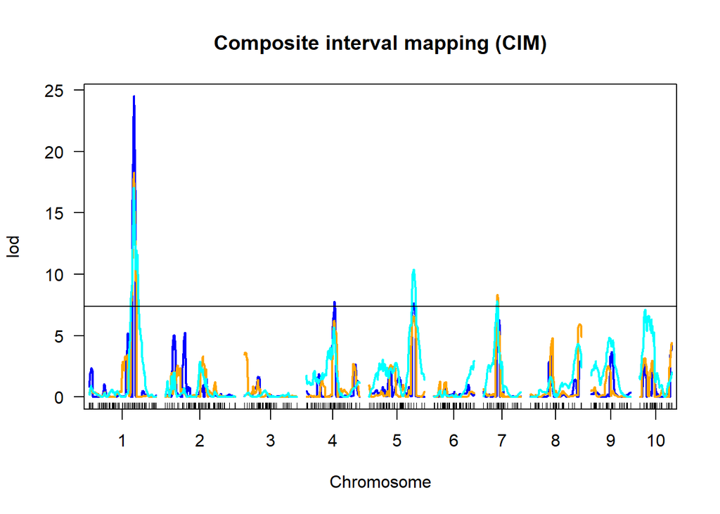

```
## integer(0)
```

```r
plot(maize.cim10, maize.cim15, maize.cimInf, col = c("blue", "orange", "cyan"), main = "Composite interval mapping (CIM)")+abline(h=perm.cim)
```

```r
maize.cim.sig <- summary(maize.cim10, threshold = perm.cim)
maize.cim.sig
```

```
##            chr   pos   lod
## c1.loc122    1 122.0 24.51
## c4.loc76     4  76.0  7.76
## c5.loc120    5 120.0  7.62
## PZA01062.1   7  39.7  7.99
```

```r
peak.markers <- which(maize.cim10$lod[maize.cim10$chr == 1] > 7.4)
maize.cim10$lod[peak.markers]
```

```
##  [1] 16.10694 21.81860 22.91849 22.91849 24.50957 23.78671 20.87421 20.87421
##  [9] 20.18195 13.58196 13.20975
```

```r
maize.cim10$pos[peak.markers]
```

```
##  [1] 118.0000 120.0000 121.1123 121.1123 122.0000 122.7166 123.6104 123.6104
##  [9] 124.0000 126.0000 126.0952
```

```r
chr <- maize.cim.sig$chr
pos <- maize.cim.sig$pos
chr
```

```
## [1] 1 4 5 7
## Levels: 1 2 3 4 5 6 7 8 9 10
```

```r
pos
```

```
## [1] 122.00000  76.00000 120.00000  39.70343
```

The next step is to show the QTL effect estimates for an RIL population. For that we use the function `sim.geno()`, then `makeqtl()` and `fitqtl()`

```r
maize.mds <- sim.geno(maize.mds, step = 1)
maize.cim.qtl <- makeqtl(cross = maize.mds, chr = chr, pos = pos)
maize.cim.qtl
```

```
##   QTL object containing imputed genotypes, with 16 imputations.
##
##       name chr     pos n.gen
## Q1 1@122.0   1 122.000     2
## Q2  4@76.0   4  76.000     2
## Q3 5@120.0   5 120.000     2
## Q4  7@39.7   7  39.703     2
```

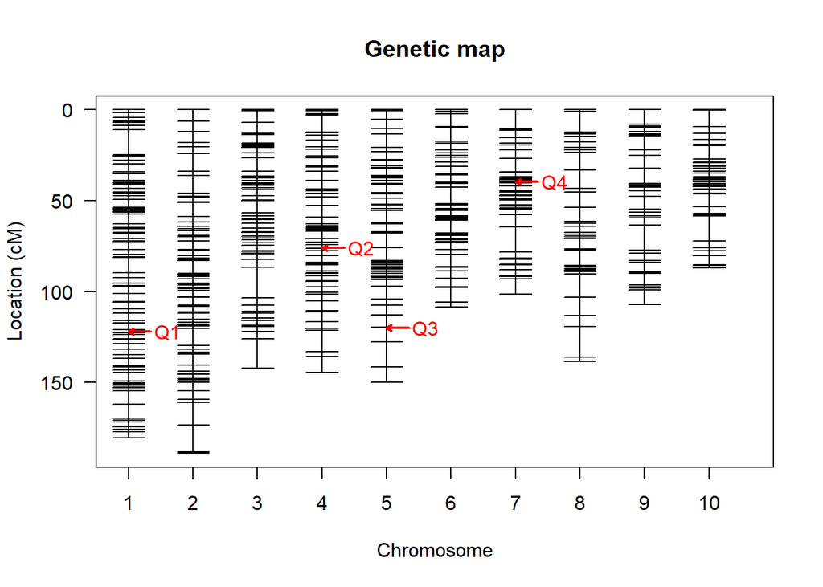

```r
plot(maize.cim.qtl)
```

```r
formula <- as.formula(paste("y", paste0("Q", c(1:length(maize.cim.sig$pos)),
                                        collapse = "+"), sep = " ~ "))
maize.cim.fit <- fitqtl(cross = maize.mds, pheno.col = "PlantHeight",
                        qtl = maize.cim.qtl, formula = formula, get.ests = TRUE)
summary(maize.cim.fit)
```

```
##
##      fitqtl summary
##
## Method: multiple imputation
## Model:  normal phenotype
## Number of observations : 185
##
## Full model result
## ----------------------------------
## Model formula: y ~ Q1 + Q2 + Q3 + Q4
##
##        df       SS        MS      LOD     %var Pvalue(Chi2)    Pvalue(F)
## Model   4 12761.48 3190.3688 16.19815 33.18332 2.442491e-15 5.329071e-15
## Error 180 25696.02  142.7557
## Total 184 38457.50
##
##
## Drop one QTL at a time ANOVA table:
## ----------------------------------
##         df Type III SS   LOD   %var F value Pvalue(Chi2) Pvalue(F)
## 1@122.0  1        5127 7.308 13.331   35.91            0  1.10e-08 ***
## 4@76.0   1        2606 3.881  6.778   18.26            0  3.12e-05 ***
## 5@120.0  1        2910 4.310  7.567   20.39            0  1.14e-05 ***
## 7@39.7   1        3121 4.606  8.117   21.87            0  5.72e-06 ***
## ---
## Signif. codes:  0 '***' 0.001 '**' 0.01 '*' 0.05 '.' 0.1 ' ' 1
##
##
## Estimated effects:
## -----------------
##                est       SE       t
## Intercept 155.9701   0.9320 167.356
## 1@122.0    -5.3696   0.9051  -5.933
## 4@76.0      3.7224   0.9263   4.019
## 5@120.0     3.8508   0.8945   4.305
## 7@39.7      4.3871   0.9712   4.517
```

```r
maize.ref <- refineqtl(cross = maize.mds, pheno.col = "PlantHeight", qtl = maize.cim.qtl, formula =  formula)
```

```
## pos: 122 76 120 39.70343
## Iteration 1
##  Q1 pos: 122 -> 121.1123
##     LOD increase:  0.123
##  Q3 pos: 120 -> 120
##     LOD increase:  0
##  Q2 pos: 76 -> 74
##     LOD increase:  0.176
##  Q4 pos: 39.70343 -> 38.40729
##     LOD increase:  0.051
## all pos: 122 76 120 39.70343 -> 121.1123 74 120 38.40729
## LOD increase at this iteration:  0.349
## Iteration 2
##  Q4 pos: 38.40729 -> 38.40729
##     LOD increase:  0
##  Q3 pos: 120 -> 120
##     LOD increase:  0
##  Q1 pos: 121.1123 -> 121.1123
##     LOD increase:  0
##  Q2 pos: 74 -> 75
##     LOD increase:  0.074
## all pos: 121.1123 74 120 38.40729 -> 121.1123 75 120 38.40729
## LOD increase at this iteration:  0.074
## Iteration 3
##  Q2 pos: 75 -> 75
##     LOD increase:  0
##  Q3 pos: 120 -> 120
##     LOD increase:  0
##  Q1 pos: 121.1123 -> 121.1123
##     LOD increase:  0
##  Q4 pos: 38.40729 -> 38.40729
##     LOD increase:  0
## all pos: 121.1123 75 120 38.40729 -> 121.1123 75 120 38.40729
## LOD increase at this iteration:  0
## overall pos: 122 76 120 39.70343 -> 121.1123 75 120 38.40729
## LOD increase overall:  0.424
```

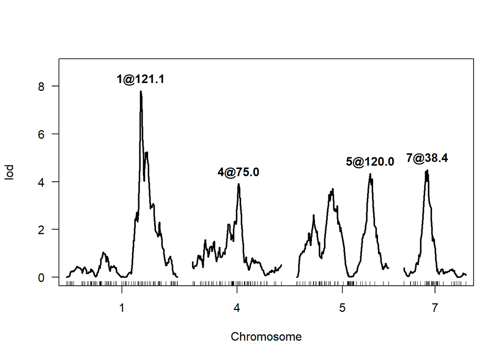

```r
plotLodProfile(maize.ref)
```

#### Multiple Interval Mapping (MIM)

Multiple interval mapping (MIM), a new statistical approach for mapping quantitative trait loci (QTL), is given. It fits multiple putative QTL directly in the model for mapping QTL using multiple marker intervals at the same time. The MIM model is based on Cockerham’s genetic parameter interpretation model and the maximum likelihood method for estimating genetic parameters. The precision and power of QTL mapping could be increased using the MIM technique. Epistasis between QTL, individual genotypic values, and quantitative trait heritabilities can also be easily quantified and studied.

```r
#perm.mim <- scantwo(maize.mds, pheno.col = "PlantHeight", method = "hk", n.perm = 1000, n.cluster = 2)
#save(perm.mim, file = "perm.mim.RData")
load("perm.mim.RData")
threshold.mim <- summary(perm.mim, alpha = 0.05)
threshold.mim
```

```
##  (1000 permutations)
##    full  fv1  int add  av1  one
## 5% 6.44 4.78 4.01 5.1 2.93 3.07
```

```r
penalties <- calc.penalties(perm.mim)
penalties
```

```
##     main    heavy    light
## 3.069812 4.008667 1.705571
```

Before applying main and interaction effect on our RIL population we estimated the permutation threshold level which are given above.

#### Main effect

To estimate main effect of the QTL on the observed trait `stepwiseqtl` function is used which can detect maximum 10 QTL based on the threshold level. So, from the graph 5 QTL were identified on chromosome 1, 4, 5, 7, 10 each and 2 QTL on chromosome 8. From the summary of the model it is observed that all the QTL have main effect on the plant height and there is interaction effect of QTL 2 and 7 was also present.

```r
maize.step <- stepwiseqtl(maize.mds, pheno.col = "PlantHeight", max.qtl = 10, method = "hk", penalties = penalties)
```

```
##  -Initial scan
## initial lod:  4.487229
## ** new best ** (pLOD increased by 1.4174)
##     no.qtl =  1   pLOD = 1.417417   formula: y ~ Q1
##  -Step 1
##  ---Scanning for additive qtl
##         plod = 3.194404
##  ---Scanning for QTL interacting with Q1
##         plod = 1.511306
##  ---Refining positions
##     no.qtl =  2   pLOD = 3.194404   formula: y ~ Q1 + Q2
## ** new best ** (pLOD increased by 1.777)
##  -Step 2
##  ---Scanning for additive qtl
##         plod = 5.525958
##  ---Scanning for QTL interacting with Q1
##         plod = 3.822307
##  ---Scanning for QTL interacting with Q2
##         plod = 3.874844
##  ---Look for additional interactions
##         plod = 1.511306
##  ---Refining positions
##     no.qtl =  3   pLOD = 5.525958   formula: y ~ Q1 + Q2 + Q3
## ** new best ** (pLOD increased by 2.3316)
##  -Step 3
##  ---Scanning for additive qtl
##         plod = 7.063851
##  ---Scanning for QTL interacting with Q1
##         plod = 5.64448
##  ---Scanning for QTL interacting with Q2
##         plod = 5.411262
##  ---Scanning for QTL interacting with Q3
##         plod = 5.421449
##  ---Look for additional interactions
##         plod = 3.874844
##  ---Refining positions
##     no.qtl =  4   pLOD = 7.063851   formula: y ~ Q1 + Q2 + Q3 + Q4
## ** new best ** (pLOD increased by 1.5379)
##  -Step 4
##  ---Scanning for additive qtl
```

[output cut: 175 more lines]

```
##  ---Refining positions
##  ---  Moved a bit
##  ---Dropping Q4
##     no.qtl =  3   pLOD = 3.666482   formula: y ~ Q1 + Q2 + Q3
##  ---Refining positions
##  ---  Moved a bit
##  ---Dropping Q3
##     no.qtl =  2   pLOD = 3.60254   formula: y ~ Q1 + Q2
##  ---Refining positions
##  ---  Moved a bit
##  ---Dropping Q2
##     no.qtl =  1   pLOD = 1.072056   formula: y ~ Q1
##  ---Refining positions
##  ---  Moved a bit
##  ---One last pass through refineqtl
```

```r
summary(maize.step)
```

```
##   QTL object containing genotype probabilities.
##
##       name chr     pos n.gen
## Q1 1@122.0   1 122.000     2
## Q2  4@77.0   4  77.000     2
## Q3 5@119.7   5 119.663     2
## Q4  7@34.2   7  34.245     2
## Q5  8@51.0   8  51.000     2
## Q6 8@132.0   8 132.000     2
## Q7 10@39.5  10  39.515     2
##
##   Formula: y ~ Q1 + Q2 + Q3 + Q4 + Q5 + Q6 + Q7 + Q2:Q7
##
##   pLOD:  8.241
```

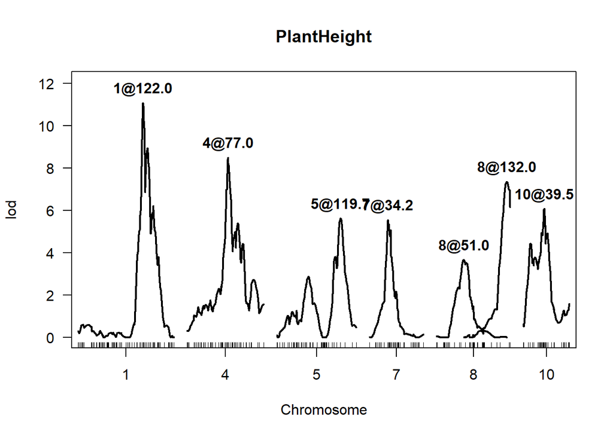

```r
plotLodProfile(maize.step, main ="PlantHeight")
```

```r
#maize.mds <- calc.genoprob(maize.mds, step = 2)
#maize.two <- scantwo(maize.mds, pheno.col = "PlantHeight", method = "hk", n.cluster = 2)
#save(maize.two, file = "maize.two.RData")
```

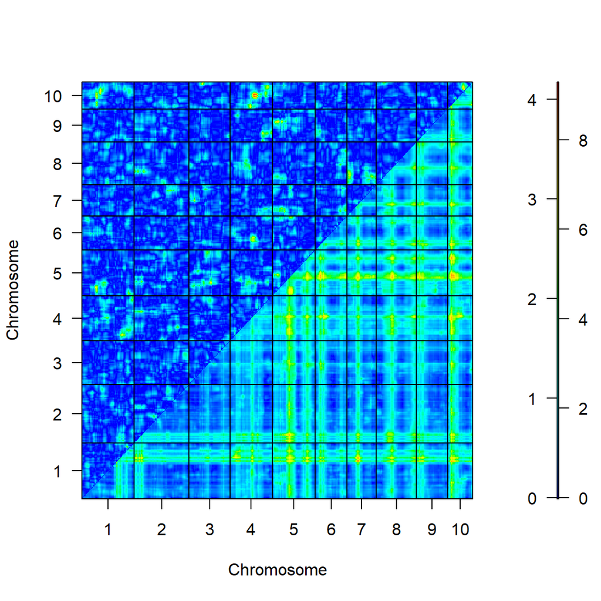

```r
load("maize.two.RData")
plot(maize.two, col.scheme = "redblue")
```

```r
summary(maize.two)
```

```
##         pos1f pos2f lod.full lod.fv1 lod.int     pos1a pos2a lod.add lod.av1
## c1 :c1    106   122     5.64   1.823 0.03700       106   122    5.60   1.786
## c1 :c2    132    24     7.25   3.428 1.16498       122    24    6.08   2.263
## c1 :c3    122    68     5.49   1.675 0.19302       122   120    5.30   1.482
## c1 :c4    122    76     7.50   3.679 0.00613       122    76    7.49   3.673
## c1 :c5    122   120     7.93   3.488 0.08971       122   120    7.84   3.398
## c1 :c6    122    18     6.45   2.629 0.10913       122    18    6.34   2.520
## c1 :c7    122    36     9.27   5.454 0.08435       122    36    9.19   5.369
## c1 :c8    122    52     7.20   3.384 0.01122       122    52    7.19   3.373
## c1 :c9    122    10     8.11   4.293 0.69859       122    10    7.41   3.595
## c1 :c10   122    14     8.64   4.523 0.03631       122    14    8.60   4.487
## c2 :c2     24    72     3.91   1.137 0.40611         6    24    3.50   0.731
## c2 :c3     24   120     4.16   1.391 0.05765        24   120    4.10   1.334
## c2 :c4     24    76     5.81   2.751 0.32870        24    76    5.48   2.422
## c2 :c5     24    58     8.28   3.841 1.54517        24    56    6.74   2.295
## c2 :c6     24    18     5.21   1.987 0.00739        24    18    5.21   1.980
## c2 :c7     24    36     6.43   3.347 0.31492        24    36    6.12   3.032
## c2 :c8     24   138     6.24   3.294 0.01395        24   138    6.22   3.280
## c2 :c9     18    10     5.78   2.766 0.40586        24    10    5.37   2.360
## c2 :c10    24    14     7.27   3.152 0.29785        24    14    6.97   2.855
## c3 :c3     68    86     3.77   2.335 0.84544        68    86    2.92   1.489
## c3 :c4     68    76     4.46   1.402 0.14866        68    76    4.31   1.253
## c3 :c5     78    58     6.11   1.670 0.44662        68    58    5.66   1.224
## c3 :c6     66    18     5.72   2.490 0.44993        68    18    5.27   2.040
## c3 :c7     56    38     5.36   2.273 0.85768        66    40    4.50   1.415
## c3 :c8    120    54     4.51   1.564 0.04156       120    54    4.47   1.523
## c3 :c9    120    10     4.64   1.626 0.00136       120    10    4.64   1.625
## c3 :c10    68    14     6.93   2.811 0.56843        68    14    6.36   2.243
## c4 :c4     28    76     4.39   1.325 0.41726        28    76    3.97   0.908
## c4 :c5     76    56     7.89   3.452 0.47173        76    58    7.42   2.981
## c4 :c6     76    28     7.88   4.654 2.31260        76    18    5.57   2.342
## c4 :c7     76    38     5.69   2.602 0.03723        76    40    5.65   2.565
## c4 :c8     76   132     6.83   3.764 0.72311        76   138    6.10   3.041
## c4 :c9     76    10     5.56   2.503 0.00361        76    10    5.56   2.500
## c4 :c10    68    12     7.93   3.814 1.44786        76    14    6.48   2.366
## c5 :c5     16    68     7.27   2.835 0.37399        58   122    6.90   2.461
## c5 :c6     64    18     8.07   3.629 0.24778        64    18    7.82   3.381
## c5 :c7     58    36     8.02   3.579 0.03229        58    36    7.99   3.547
## c5 :c8     60    56     7.77   3.331 0.13920        58    54    7.63   3.192
## c5 :c9     58    10     8.22   3.781 0.53252        58    10    7.69   3.248
## c5 :c10    66    14     8.46   4.022 0.24666        66    14    8.22   3.776
## c6 :c6     18    92     5.25   2.028 0.33042        18    88    4.92   1.698
## c6 :c7     18    40     6.30   3.071 0.20512        28    36    6.09   2.866
## c6 :c8     18   138     6.79   3.567 0.73411        18   138    6.06   2.833
## c6 :c9     28    10     6.19   2.962 0.59134        18    10    5.60   2.370
## c6 :c10    18    12     7.73   3.609 0.82172        18    12    6.90   2.787
## c7 :c7     28    36     4.26   1.179 0.11576         0    36    4.15   1.063
## c7 :c8     38    54     6.24   3.156 0.30408        36   138    5.94   2.851
## c7 :c9     36    10     6.19   3.106 0.11261        36    10    6.08   2.993
## c7 :c10    36    12     7.21   3.089 0.00500        36    12    7.20   3.084
## c8 :c8     54   138     6.26   3.321 0.16220        54   138    6.10   3.159
## c8 :c9    138    10     6.00   2.989 0.63096       138    10    5.37   2.358
## c8 :c10   138    14     6.61   2.494 0.14232       138    14    6.47   2.352
## c9 :c9     10    40     3.98   0.963 0.26551        10    94    3.71   0.698
## c9 :c10    10    12     6.98   2.862 0.55067        10    14    6.43   2.312
## c10:c10    14    86     6.87   2.749 0.50126        14    86    6.37   2.248
```

## Discussion

In this study, a total of 7 QTL were identified for PH by multiple interval mapping approach and 4 by CIM approach by using mean field data of the trait. In maize, several studies reported that QTL effects for plant height are largely independent of the environment, despite the presence of significant genotype by environment interaction (Stuber et al. 1992; Melchinger, Utz, and Schön 1998). For only QTL present on chromosome 1, alleles from recessive parent were going towards decreasing the PH values. The distribution of the QTLs for the genome showed a high concentration of QTLs in few chromosome regions. Such a concentration in the distribution of QTLs has already been observed in other studies (Stuber et al. 1992; Abler, Edwards, and Stuber 1991; Veldboom, Lee, and Woodman 1994). The QTLs consistently detected through all methods used favoring their use in future programs for marker-assisted selection (MAS), if the objective is selecting stable QTLs. The use of molecular markers has provided the potential to construct saturated plant genetic maps and to provide insights into the genomic location and gene action of individual QTL (Lander and Botstein 1989) and the potential to enhance the efficiency of trait selection in plant breeding. Marker-assistant selection is one of the most important research directions in the molecular breeding. With the studies focused on molecular-assisted selection of qualitative traits, however, there are only a few cases to apply molecular marker-assisted selection to quantitative traits.

## Conclusion

In this study, we systematically analyzed plant height traits and identified QTL by using SMA, IM, CIM and MIM methodology. Three consistent QTL with stable main effects in were obtained, but one of them has negative main effect on our trait of interest. The study of plant height is of great significance to the cultivation of new high-quality and high-yield maize germplasm. These results laid the foundation for the molecular mechanism, genetic and marker-assisted breeding for maize plant height, commercially important trait to avoid lodging.

## References

Abler, BSB, MD Edwards, and CW Stuber. 1991. “Isoenzymatic Identification of Quantitative Trait Loci in Crosses of Elite Maize Inbreds.” *Crop Science* 31 (2): 267–74.

Broman, Karl W., Hao Wu, Śaunak Sen, and Gary A. Churchill. 2003. “R/Qtl: QTL Mapping in Experimental Crosses.” *Bioinformatics* 19: 889–90. https://doi.org/10.1093/bioinformatics/btg112.

Cao, Yongguo, Guoying Wang, Shoucai Wang, Yanling Wei, Jiang Lu, Youju Xie, and Jingrui Dai. 2000. “Construction of a Genetic Map and Location of Quantitative Trait Loci for Dwarf Trait in Maize by RFLP Markers.” *Chinese Science Bulletin* 45 (3): 247–50.

Churchill, Gary A, and RW1206241 Doerge. 1994. “Empirical Threshold Values for Quantitative Trait Mapping.” *Genetics* 138 (3): 963–71.

Coe, EH, D Hoisington, S Chao, et al. 1990. “Gene List and Working Maps.” *Maize Genetics Cooperation News Letter*, no. 64: 134–63.

Doerge, Rebecca W, and GA1206957 Churchill. 1996. “Permutation Tests for Multiple Loci Affecting a Quantitative Character.” *Genetics* 142 (1): 285–94.

Doerge, RW, and Ahmed Rebaı̈. 1996. “Significance Thresholds for QTL Interval Mapping Tests.” *Heredity* 76 (5): 459–64.

Kao, Chen-Hung, Zhao-Bang Zeng, and Robert D Teasdale. 1999. “Multiple Interval Mapping for Quantitative Trait Loci.” *Genetics* 152 (3): 1203–16.

Lander, Eric S, and David Botstein. 1989. “Mapping Mendelian Factors Underlying Quantitative Traits Using RFLP Linkage Maps.” *Genetics* 121 (1): 185–99.

Melchinger, Albrecht E, H Friedrich Utz, and Chris C Schön. 1998. “Quantitative Trait Locus (QTL) Mapping Using Different Testers and Independent Population Samples in Maize Reveals Low Power of QTL Detection and Large Bias in Estimates of QTL Effects.” *Genetics* 149 (1): 383–403.

RStudio Team. 2022. *RStudio: Integrated Development Environment for r*. Boston, MA: RStudio, PBC. http://www.rstudio.com/.

Stuber, Charles W, Stephen E Lincoln, DW Wolff, T Helentjaris, and ES1205218 Lander. 1992. “Identification of Genetic Factors Contributing to Heterosis in a Hybrid from Two Elite Maize Inbred Lines Using Molecular Markers.” *Genetics* 132 (3): 823–39.

Veldboom, LR, M Lee, and WL Woodman. 1994. “Molecular Marker-Facilitated Studies in an Elite Maize Population: I. Linkage Analysis and Determination of QTL for Morphological Traits.” *Theoretical and Applied Genetics* 88 (1): 7–16.

Zeng, Zhao-Bang. 1994. “Precision Mapping of Quantitative Trait Loci.” *Genetics* 136 (4): 1457–68.

Zhang, ZM, MJ Zhao, HP Ding, TZ Rong, and GT Pan. 2006. “Quantitative Trait Loci Analysis of Plant Height and Ear Height in Maize (Zea Mays l.).” *Russian Journal of Genetics* 42 (3): 306–10.